# MSR-DS3 Research Replication

Limor Kohanim & Sushobhan Parajuli

6/24/2022

```r
suppressMessages(library(tidyverse))
suppressMessages(library(lubridate))
suppressMessages(library(ggplot2))
suppressMessages(library(modelr))
suppressMessages(library(broom))
suppressMessages(library(gridExtra))
suppressMessages(library(scales))
suppressMessages(library(tigris))
options(tigris_use_cache = TRUE)
```

## Differential COVID-19 case positivity in New York City neighborhoods: Socioeconomic factors and mobility

#### Click for the [ORIGINAL ARTICLE](https://onlinelibrary.wiley.com/doi/epdf/10.1111/irv.12816)

## Overview of the article

The article written during early stages of COVID-19 pandemic studied different socioeconomic factors and COVID-19 positive cases in New York City (NYC) by Zip codes. The study examined the extent to which the variability in Zip code-level case positivity can be explained by socioeconomic factors and daily change in mobility. The study reported that the socioeconomic factors considered together explained 56% of the variability in case positivity through April 1. Further, the study analyzed effects of socioeconomic factors on case positivity after addition of changes in mobility and reported that changes in mobility were not likely to be acting as mediator, they analyzed this by comparing R-squared values in the multivariable linear regression model with changes in mobility as a feature with the multivariable linear regression model without changes in mobility.

The socioeconomic factors reported are proportion of the 18 to 64 year-old population that is uninsured, median household income(in 2016 dollars), proportion of population living in households with more than three inhabitants, proportion of population using public transportation to commute to work that includes bus travel, and proportion of population that is elderly (65+ years of age).

In this notebook, we are trying to replicate these finding and achieve similar results. We analyze the variability in Zip code-level case positivity resulted by an each socioeconomic factor alone, and by socioeconomic factors considered together without and with changes in mobility. We take six socioeconomic factors that are used in the article and plot heat maps for each. We plot distribution of changes in mobility per day for March and April of 2020 in violin plots and examine its trend.

## Data

We extracted data for socioeconomic status from United States Census Bureau and saved it in an Rdata file *socioeconomic.Rdata*. You can access the code [here](https://github.com/msr-ds3/covid-nyc-2022-group-5/blob/main/figure_1_final.Rmd).

We accessed the list of NYC Zip codes from [here](https://raw.githubusercontent.com/erikgregorywebb/nyc-housing/master/Data/nyc-zip-codes.csv).

We used [this](https://raw.githubusercontent.com/nychealth/coronavirus-data/097cbd70aa00eb635b17b177bc4546b2fce21895/tests-by-zcta.csv) dataset to access COVID-19 tests and positive cases for all NYC zip codes.

We accessed mobility data from our R studio server and it is not publicly available.

```r
# Load Rdata files

load("socioeconomic.Rdata")
load("mobility.Rdata")

# Get zip codes

nyc_zip_codes <- read_csv(
  "https://raw.githubusercontent.com/erikgregorywebb/nyc-housing/master/Data/nyc-zip-codes.csv", show_col_types = FALSE)

# Get COVID-19 data

tests_by_zcta <- read_csv(
  "https://raw.githubusercontent.com/nychealth/coronavirus-data/097cbd70aa00eb635b17b177bc4546b2fce21895/tests-by-zcta.csv", show_col_types = FALSE)
```

## Variability in socioeconomic status among different zip codes in NYC

We replicate heat maps from the original article that show how socioeconomic factors vary among Zip codes in NYC.

The resulting plot looks identical to the one plotted in the original article.

### Heat maps for soceoeconomic factors

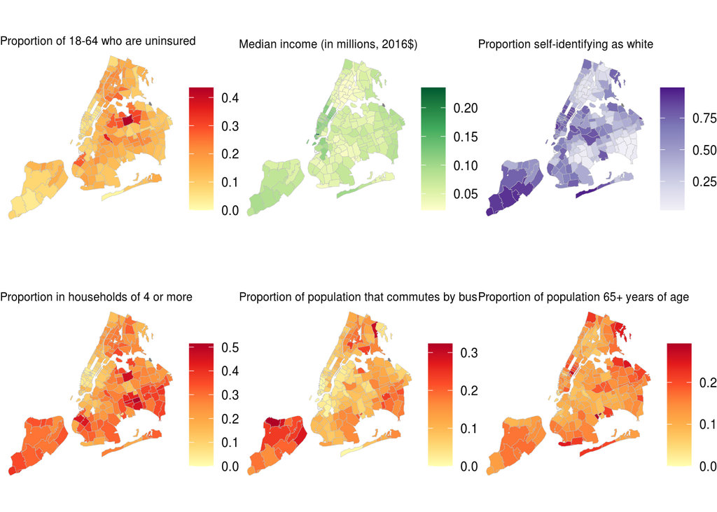

```r
# Plot for proportion of uninsured population
plot_1 <- ggplot(data = uninsured,
       mapping = aes(fill = uninsured$prop)) +
  geom_sf(data = uninsured$geometry, color = "gray", lwd = 0.1) +
  scale_fill_distiller(palette = "YlOrRd", direction = 1) +
  theme_void() +
  labs(title = "Proportion of 18-64 who are uninsured",
       fill = "") +
  theme(plot.title = element_text(size=8))

# Plot for median income
plot_2 <- ggplot(data = median_income,
       mapping = aes(fill = median_income$estimate)) +
  geom_sf(data = median_income$geometry, color = "gray", lwd = 0.1) +
  scale_fill_distiller(palette = "YlGn", direction = 1) +
  theme_void() +
  labs(title = "Median income (in millions, 2016$)",
       fill = "") +
  theme(plot.title = element_text(size=8))

# Plot for proportion of self-identifying as white
plot_3 <- ggplot(data = selfid_whites,
       mapping = aes(fill = selfid_whites$prop)) +
  geom_sf(data = selfid_whites$geometry, color = "gray", lwd = 0.1) +
  scale_fill_distiller(palette = "Purples", direction = 1) +
  theme_void() +
  labs(title = "Proportion self-identifying as white",
       fill = "") +
  theme(plot.title = element_text(size=8))

# Plot for proportion in households of 4 or more
plot_4 <- ggplot(data = households4,
       mapping = aes(fill = households4$prop)) +
  geom_sf(data = households4$geometry, color = "gray", lwd = 0.1) +
  scale_fill_distiller(palette = "YlOrRd", direction = 1) +
  theme_void() +
  labs(title = "Proportion in households of 4 or more",
       fill = "") +
  theme(plot.title = element_text(size=8))

# Plot for proportion of population that commutes by bus
plot_5 <- ggplot(data = commutebybus,
       mapping = aes(fill = commutebybus$prop)) +
  geom_sf(data = commutebybus$geometry, color = "gray", lwd = 0.1) +
  scale_fill_distiller(palette = "YlOrRd", direction = 1) +
  theme_void() +
  labs(title = "Proportion of population that commutes by bus",
       fill = "") +
  theme(plot.title = element_text(size=8))

# Plot for proportion of elderly population
plot_6 <- ggplot(data = pop65andabove,
       mapping = aes(fill = pop65andabove$prop)) +
  geom_sf(data = pop65andabove$geometry, color = "gray", lwd = 0.1) +
  scale_fill_distiller(palette = "YlOrRd", direction = 1) +
  theme_void() +
  labs(title = "Proportion of population 65+ years of age",
       fill = "") +
  theme(plot.title = element_text(size=8))

grid.arrange(plot_1, plot_2, plot_3, plot_4, plot_5, plot_6,
             ncol = 3)
```

## Simple Linear Regression models for COVID-19 positive cases

Now, we build models for COVID-19 positive cases where we take each socioeconomic status as our feature.

```r
# First, let's change the type of zip codes to character and mutate a new column in the test_by_zcta dataset that will store proportion of positive cases.

tests_by_zcta$MODZCTA <- as.character(tests_by_zcta$MODZCTA)
tests_by_zcta <- mutate(tests_by_zcta, positive_prop = Positive / Total)
```

### Feature: proportion of 18-64 who are uninsured

```r
tests_uninsured <- inner_join(uninsured, tests_by_zcta, by = c("GEOID" = "MODZCTA"))
model_1 <- lm(positive_prop ~ prop, data=tests_uninsured)
glance(model_1)
```

```
## # A tibble: 1 × 12
##   r.squared adj.r.squared  sigma statistic  p.value    df logLik   AIC   BIC
##       <dbl>         <dbl>  <dbl>     <dbl>    <dbl> <dbl>  <dbl> <dbl> <dbl>
## 1     0.344         0.341 0.0760      90.4 1.74e-17     1   203. -399. -390.
## # … with 3 more variables: deviance <dbl>, df.residual <int>, nobs <int>
```

R-squared value with uninsured proportin of 18-64 year old people as the explanatory variabel is 34% compared to 38% in the original paper.

### Feature: median income

```r
tests_median_income <- inner_join(median_income, tests_by_zcta, by = c("GEOID" = "MODZCTA"))
model_2 <- lm(positive_prop ~ estimate, data=tests_median_income)
glance(model_2)
```

```
## # A tibble: 1 × 12
##   r.squared adj.r.squared  sigma statistic  p.value    df logLik   AIC   BIC
##       <dbl>         <dbl>  <dbl>     <dbl>    <dbl> <dbl>  <dbl> <dbl> <dbl>
## 1     0.330         0.326 0.0768      84.6 1.18e-16     1   201. -395. -386.
## # … with 3 more variables: deviance <dbl>, df.residual <int>, nobs <int>
```

R-squared value for the above model is 33% as compared to 32% in the original paper.

### Feature: proportion self-identifying as white

```r
tests_white <- inner_join(selfid_whites, tests_by_zcta, by = c("GEOID" = "MODZCTA"))
model_3 <- lm(positive_prop ~ prop, data=tests_white)
glance(model_3)
```

```
## # A tibble: 1 × 12
##   r.squared adj.r.squared  sigma statistic  p.value    df logLik   AIC   BIC
##       <dbl>         <dbl>  <dbl>     <dbl>    <dbl> <dbl>  <dbl> <dbl> <dbl>
## 1     0.335         0.331 0.0766      86.5 6.28e-17     1   201. -396. -387.
## # … with 3 more variables: deviance <dbl>, df.residual <int>, nobs <int>
```

We get R-squared value of 33% for the model with proportion of self-identified white population compared to 34% in the original paper.

### Feature: proportion in households of 4 or more

```r
tests_households <- inner_join(households4, tests_by_zcta, by = c("GEOID" = "MODZCTA"))
model_4 <- lm(positive_prop ~ prop, data=tests_households)
glance(model_4)
```

```
## # A tibble: 1 × 12
##   r.squared adj.r.squared  sigma statistic  p.value    df logLik   AIC   BIC
##       <dbl>         <dbl>  <dbl>     <dbl>    <dbl> <dbl>  <dbl> <dbl> <dbl>
## 1     0.381         0.377 0.0739      106. 1.23e-19     1   207. -409. -399.
## # … with 3 more variables: deviance <dbl>, df.residual <int>, nobs <int>
```

38% of the total variability by zip code in COVID-19 positivity is explained by a linear relationship with the proportion of the zip code living in a household with 4 or more individuals. The original paper reported 41%.

### Feature: proportion of population that commuts by bus

```r
test_commutebybus <- inner_join(commutebybus, tests_by_zcta, by = c("GEOID" = "MODZCTA"))
model_5 <- lm(positive_prop ~ prop, data=test_commutebybus)
glance(model_5)
```

```
## # A tibble: 1 × 12
##   r.squared adj.r.squared  sigma statistic    p.value    df logLik   AIC   BIC
##       <dbl>         <dbl>  <dbl>     <dbl>      <dbl> <dbl>  <dbl> <dbl> <dbl>
## 1     0.118         0.112 0.0882      22.9 0.00000361     1   177. -347. -338.
## # … with 3 more variables: deviance <dbl>, df.residual <int>, nobs <int>
```

12% of total variability by zip code in COVID-19 positivity is explained by a linear ralationship with the proportion of the zip code using bus for commute. This was reported to be 13% in the original paper.

### Feature: proportion of population 65+ years of age

```r
test_pop65andabove <- inner_join(pop65andabove, tests_by_zcta, by = c("GEOID" = "MODZCTA"))
model_6 <- lm(positive_prop ~ prop, data=test_pop65andabove)
glance(model_6)
```

```
## # A tibble: 1 × 12
##   r.squared adj.r.squared  sigma statistic p.value    df logLik   AIC   BIC
##       <dbl>         <dbl>  <dbl>     <dbl>   <dbl> <dbl>  <dbl> <dbl> <dbl>
## 1    0.0268        0.0212 0.0926      4.74  0.0308     1   168. -330. -321.
## # … with 3 more variables: deviance <dbl>, df.residual <int>, nobs <int>
```

We get R-squared value as same as reported in the original paper, which is 3%, with the model against proportion of elderly people.

## Multivariable Regression model for COVID-19 positive cases

We build a multivariable regression model for COVID-19 positive cases where we take four out of six socioeconomic factors as our features. As done in the original article, we add variables in decreasing order of their R-squared value. We add proportion living in households with four or more individuals, proportion of adults who were uninsured, proportion iden-tifying as white, and median household income. Further addition of variables results in marginal changes.

### Features: proportion living in households with four or more individuals, proportion of adults who were uninsured, proportion identifying as white, and median household income

```r
# Select the column containing features from the data sets
households4 <- select(households4, GEOID, households_prop = prop)
uninsured <- select(uninsured, GEOID, uninsured_prop = prop)
selfid_whites <- select(selfid_whites, GEOID, selfid_whites_prop = prop)
median_income <- select(median_income, GEOID, median_income_est = estimate)
commutebybus <- select(commutebybus, GEOID, commutebybus_prop = prop)
pop65andabove <- select(pop65andabove, GEOID, pop65andabove_prop = prop)

# Merge all in a dataframe and join with the COVID-19 positive tests data set
ses <- list(households4, uninsured, selfid_whites, median_income)
ses <- ses %>% reduce(full_join, by='GEOID')
test_ses <- inner_join(ses, tests_by_zcta, by = c("GEOID" = "MODZCTA"))

# Build the model
model <- lm(positive_prop ~ households_prop + uninsured_prop + selfid_whites_prop + median_income_est, data=test_ses)
```

```r
glance(model)
```

```
## # A tibble: 1 × 12
##   r.squared adj.r.squared  sigma statistic  p.value    df logLik   AIC   BIC
##       <dbl>         <dbl>  <dbl>     <dbl>    <dbl> <dbl>  <dbl> <dbl> <dbl>
## 1     0.551         0.540 0.0634      51.9 1.94e-28     4   235. -459. -440.
## # … with 3 more variables: deviance <dbl>, df.residual <int>, nobs <int>
```

R-squared value for our multivariable regression model is 55% compared to 56% in the original article.

```r
tidy(model)
```

```
## # A tibble: 5 × 5
##   term               estimate std.error statistic  p.value
##   <chr>                 <dbl>     <dbl>     <dbl>    <dbl>
## 1 (Intercept)          0.478     0.0287     16.6  2.03e-37
## 2 households_prop      0.316     0.0540      5.85 2.49e- 8
## 3 uninsured_prop       0.237     0.102       2.32 2.13e- 2
## 4 selfid_whites_prop  -0.0815    0.0244     -3.34 1.01e- 3
## 5 median_income_est   -0.522     0.245      -2.13 3.43e- 2
```

The estimates from our multivariable model are close to what the original paper reported.

## Change in mobility relative to baseline

Next, we plot the second plot from the article. The plot contains violin plolt for each day in March and April of 2020. The violins represent distribution of mobility on that day. Mobility is definied as the movement of people to point of interests (POI). We take median of average visits per day (to POIs) from pre-pandemic as our baseline. Then we calculate change in mobility in a day relative to the baseline. Here, we could access the data for only February to model our baseline, however the article uses data from September to February. This could lead to changes in our plot, however it should produce similar trend.

### Plot for change in mobility relative to baseline

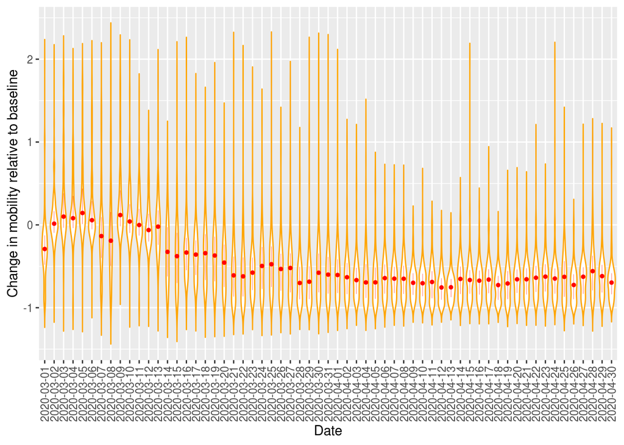

```r
ggplot() +
  geom_violin(data = mobility,
              mapping = aes(x = as.factor(date), y = delta),
              color = "orange",
              trim = F)+
  geom_pointrange(data = mobility_summary,
                  mapping = aes(x = as.factor(date),
                                ymin = twentyfive_delta,
                                y = median_delta,
                                ymax = seventyfive_delta),
                  color ="red",
                  size = 0.1) +
  theme(axis.text.x = element_text(angle = 90, vjust = 0.5, hjust=1)) +
  xlab("Date")+
  ylab("Change in mobility relative to baseline")
```

The plot follows a similar trend as in the original article. The change in mobility starts decreasing as we move along the dates.

## Effect due to change in mobility

Now we examine if there was any effect in the model as we add change in mobility. First we build a multivariable regression model with six socioeconomic factors as features, then we build another multivariable regression model with six socioeconomic factors and change in mobility as features. The original paper reported that there is no effect of this variable to the COVID-19 positive cases based on R-squared vlues.

### Features: all six socioeconomic factors

```r
#put all data frames into list
ses <- list(households4, uninsured, selfid_whites, median_income, commutebybus, pop65andabove)

#merge all data frames in list
ses <- ses %>% reduce(full_join, by='GEOID')

test_ses <- inner_join(ses, tests_by_zcta, by = c("GEOID" = "MODZCTA"))

model_ses<- lm(positive_prop ~ households_prop + uninsured_prop + selfid_whites_prop + median_income_est + commutebybus_prop + pop65andabove_prop, data=test_ses)
```

```r
glance(model_ses)
```

```
## # A tibble: 1 × 12
##   r.squared adj.r.squared  sigma statistic  p.value    df logLik   AIC   BIC
##       <dbl>         <dbl>  <dbl>     <dbl>    <dbl> <dbl>  <dbl> <dbl> <dbl>
## 1     0.561         0.546 0.0631      35.6 1.49e-27     6   237. -459. -434.
## # … with 3 more variables: deviance <dbl>, df.residual <int>, nobs <int>
```

### Features: all six socioeconomic factors and change in mobility

```r
# Get april 1st mobility change per zipcode, filter mobility's dates to april 1st

mobility_changes <- mobility %>% filter(date == "2020-04-01")

# Add zip codes/postal codes to mobility_changes

mobility_changes$postal_code <- as.character(mobility_changes$postal_code)

test_ses_mob <- inner_join(test_ses, mobility_changes, by = c("GEOID" = "postal_code"))

model_ses_mob<- lm(positive_prop ~ households_prop + uninsured_prop + selfid_whites_prop + median_income_est + commutebybus_prop + pop65andabove_prop + delta, data=test_ses_mob)
```

```r
glance(model_ses_mob)
```

```
## # A tibble: 1 × 12
##   r.squared adj.r.squared  sigma statistic  p.value    df logLik   AIC   BIC
##       <dbl>         <dbl>  <dbl>     <dbl>    <dbl> <dbl>  <dbl> <dbl> <dbl>
## 1     0.567         0.549 0.0631      30.3 1.58e-26     7   232. -447. -419.
## # … with 3 more variables: deviance <dbl>, df.residual <int>, nobs <int>
```